# Neoplasia e Anomalia X Agrotóxicos na água

Viviane Serra Melanda, Humberto Cereser Ibanez, Cláudia Sirlene de Oliveira e [Henrique Laureano](https://henriquelaureano.github.io/)

Last modification on* 2021-12-23 16:45:01

# estat_sia_sih_agrot_corr

## Indicadores

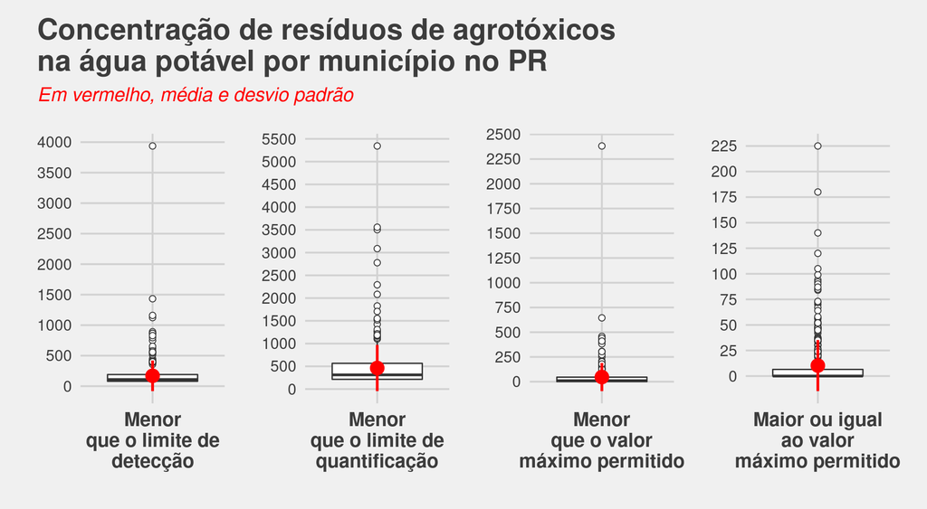

Medidas descritivas

| agr | Mínimo | 1o Quartil | Mediana | Média | 3o Quartil | Máximo | Desvio Padrão |
| --- | --- | --- | --- | --- | --- | --- | --- |
| agrmenld14a20 | 0 | 80 | 109 | 169.85 | 190.5 | 3937 | 251.06 |
| agrmenlq14a20 | 0 | 214 | 312 | 462.51 | 566.0 | 5344 | 507.81 |
| agrmenvmp14a20 | 0 | 1 | 10 | 46.84 | 46.0 | 2382 | 142.14 |
| agrmaiguvmp14a20 | 0 | 0 | 0 | 10.26 | 6.5 | 225 | 24.99 |

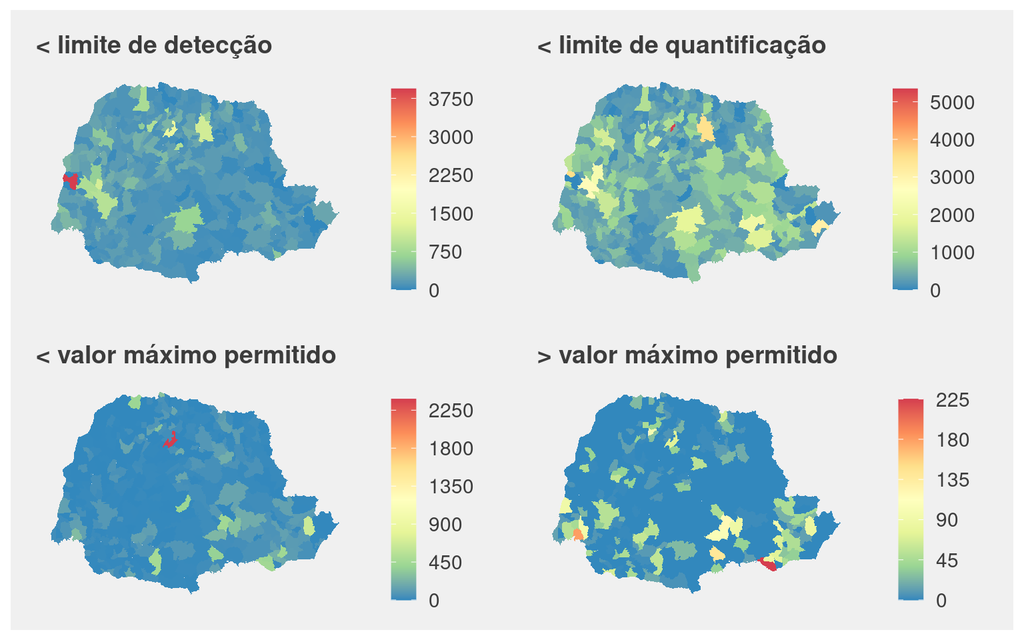

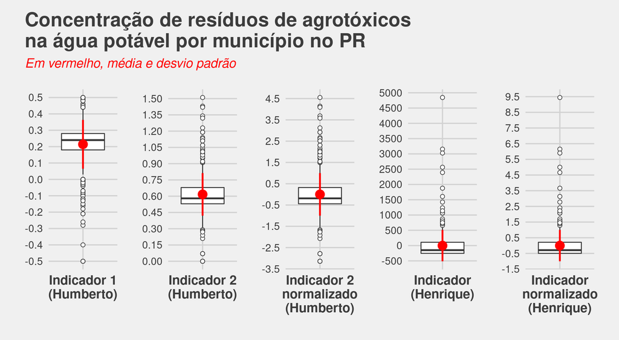

Medidas descritivas

| type | Mínimo | 1o Quartil | Mediana | Média | 3o Quartil | Máximo | Desvio Padrão |
| --- | --- | --- | --- | --- | --- | --- | --- |
| agrindic1 | -0.50 | 0.18 | 0.24 | 0.21 | 0.28 | 0.50 | 0.15 |
| agrindic2 | 0.00 | 0.53 | 0.58 | 0.62 | 0.68 | 1.51 | 0.20 |
| agrindic2_scaled | -3.14 | -0.44 | -0.19 | 0.00 | 0.32 | 4.55 | 1.00 |
| indicador | -483.84 | -253.99 | -149.65 | 0.00 | 108.55 | 4844.87 | 512.97 |
| indicador_scaled | -0.94 | -0.50 | -0.29 | 0.00 | 0.21 | 9.44 | 1.00 |

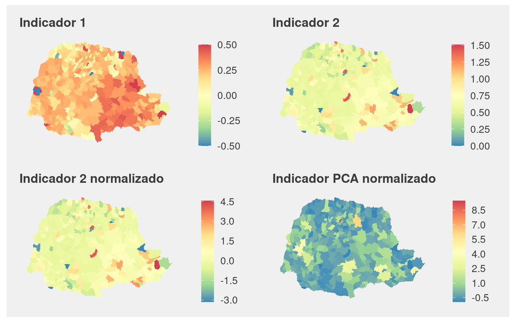

> Pesos (os indicadores propostos por Humberto possuem pesos dinâmicos, variando dependendo do número/quantidade de registros. Bem interessante):

|  | agrmenld14a20 | agrmenlq14a20 | agrmenvmp14a20 | agrmaiguvmp14a20 |
| --- | --- | --- | --- | --- |
| Primeiro autovetor (pesos) | 0.16021136889 | 0.987077983839 | 0.002477639441 | -0.001797888356 |
| Indicador 1 | -0.5/qt_registros | -0.7/qt_registros | 1.2/qt_registros | 1.3/qt_registros |
| Indicador 2 | 0.07/qt_registros | 0.71/qt_registros | 1.43/qt_registros | 2.14/qt_registros |

> Variância explicada por cada componente principal:

```
[1] 0.770 0.173 0.056 0.001
```

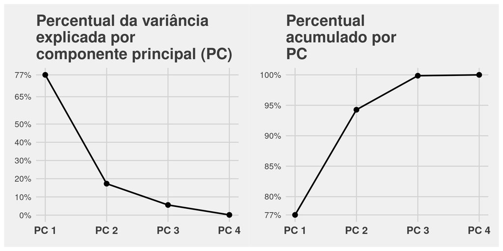

> Com os quatro componentes principais explicamos 100% da variabilidade presente/gerada pelas quatro medidas. Apenas com o primeiro componente principal conseguimos explicar 77% dessa variabilidade.

# Associações

## anomalia_neoplasia_08a18

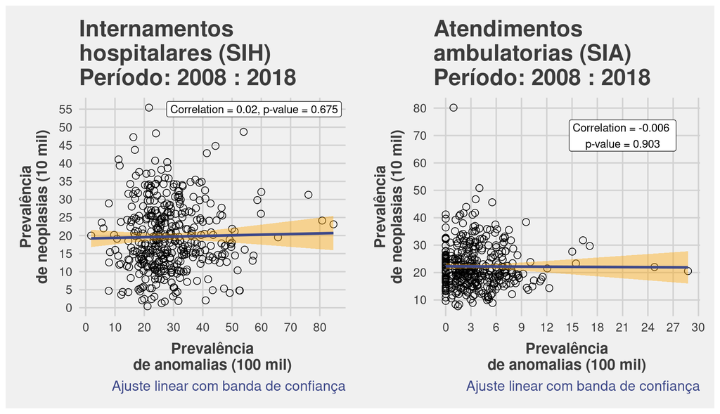

> Com base nos gráficos de dispersão e cálculos de correlação linear de Pearson, não temos evidências de associação entre as prevalências de anomalias com as de neoplasias. Consequentemente, quando ajustarmos os modelos espaciais as prevalências de anomalias muito provavelmente terão efeito *não* significativo nas prevailências de neoplasias.

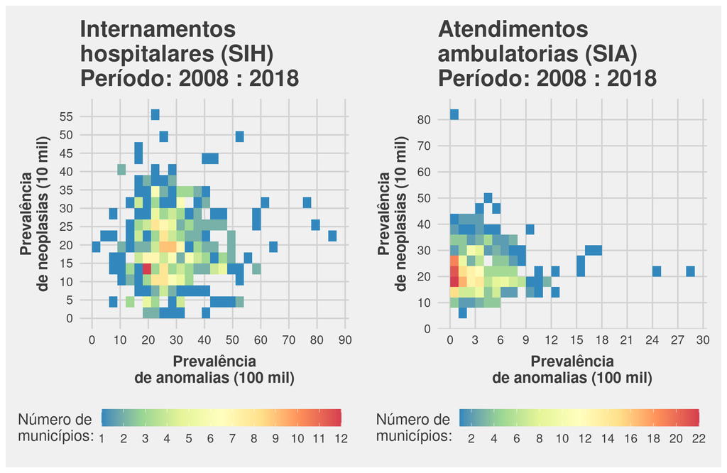